# Practical Machine Learning Project Write up

Fernando Gonzalez Prada

July 25th, 2015

## Background

Using devices such as Jawbone Up, Nike FuelBand, and Fitbit it is now possible to collect a large amount of data about personal activity relatively inexpensively. These type of devices are part of the quantified self movement - a group of enthusiasts who take measurements about themselves regularly to improve their health, to find patterns in their behavior, or because they are tech geeks. One thing that people regularly do is quantify how much of a particular activity they do, but they rarely quantify how well they do it. In this project, your goal will be to use data from accelerometers on the belt, forearm, arm, and dumbell of 6 participants. They were asked to perform barbell lifts correctly and incorrectly in 5 different ways. More information is available from the website here: http://groupware.les.inf.puc-rio.br/har (see the section on the Weight Lifting Exercise Dataset).

# Data

The training data for this project are available here:

https://d396qusza40orc.cloudfront.net/predmachlearn/pml-training.csv

The test data are available here:

https://d396qusza40orc.cloudfront.net/predmachlearn/pml-testing.csv

The data for this project come from this source: http://groupware.les.inf.puc-rio.br/har. If you use the document you create for this class for any purpose please cite them as they have been very generous in allowing their data to be used for this kind of assignment.

# Load the packages

```r
library(caret)
library(randomForest)
library(e1071)
```

# Read the data files into R data frames:

```r
train <- read.csv("pml-training.csv", row.names = 1, header = TRUE, na.strings = c("NA","","#DIV/0!"))
test <- read.csv("pml-testing.csv", row.names = 1, header = TRUE, na.strings = c("NA","","#DIV/0!"))
dim(train)
```

```
## [1] 19622   159
```

The training set consists of 19622 rows and 159 columns.

# Data Cleaning

The files are loaded mapping the NA, “” and “”#DIV/0!“” values into NA for missing values handling. The are a lot of NA values present in multiple variables. To preserve the space of this report, the summary() command output is omitted,

Remove the near zero variance predictors, to reduce the total size of the data frame

```r
nzv_cols <- nearZeroVar(train[, -159])
if(length(nzv_cols) > 0)
    train <- train[, -nzv_cols]
dim(train)
```

```
## [1] 19622   123
```

The next step involves deleting the remaining columns that contains values with NA. These columns has almost all the values in NA, so we decided to delete the columns.

```r
train = train[ , colSums(is.na(train)) == 0]
dim(train)
```

```
## [1] 19622    58
```

Finally, the data frame has 58 variables.

## Random Forest Model

After trying different models, the best results were obtained with Random Forest. The solution involves fiting the algorithm performing 10-fold cross validation to predict the target variable “classe”.

```r
set.seed(1000)

# rfModel <- train(classe ~ .,
#               method = "rf",
#               data = train,
#               importance = T,
#               trControl = trainControl(method = "cv", number = 10))
load("rfModel_fsgp.rda")
rfModel
```

```
## Random Forest
##
## 19622 samples
##    57 predictor
##     5 classes: 'A', 'B', 'C', 'D', 'E'
##
## No pre-processing
## Resampling: Cross-Validated (10 fold)
##
## Summary of sample sizes: 17660, 17659, 17660, 17660, 17661, 17660, ...
##
## Resampling results across tuning parameters:
##
##   mtry  Accuracy   Kappa      Accuracy SD   Kappa SD
##    2    0.9919474  0.9898126  0.0026407557  0.0033418245
##   40    0.9992864  0.9990974  0.0006881068  0.0008703797
##   79    0.9991336  0.9989041  0.0007614714  0.0009631631
##
## Accuracy was used to select the optimal model using  the largest value.
## The final value used for the model was mtry = 40.
```

The accuracy of this Random Forest Model is 99%, quite impressive.

# Accuracy Chart

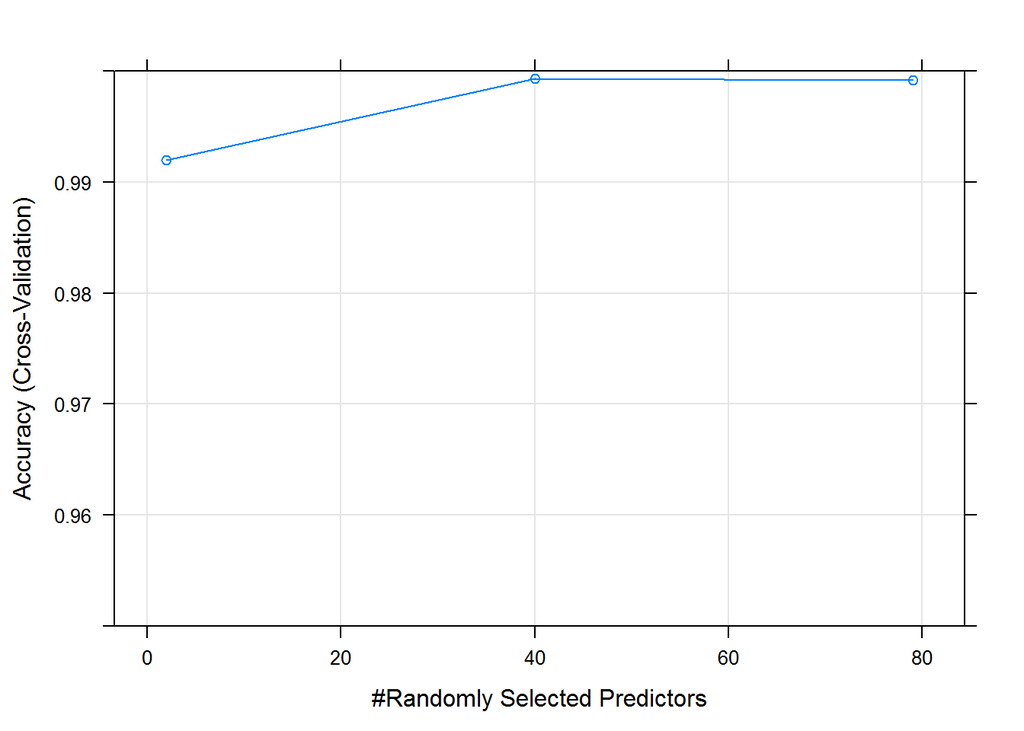

```r
plot(rfModel, ylim = c(0.95, 1))
```

# Final model and prediction

```r
rfModel$finalModel
```

```
##
## Call:
##  randomForest(x = x, y = y, mtry = param$mtry, importance = ..1)
##                Type of random forest: classification
##                      Number of trees: 500
## No. of variables tried at each split: 40
##
##         OOB estimate of  error rate: 0.04%
## Confusion matrix:
##      A    B    C    D    E  class.error
## A 5580    0    0    0    0 0.0000000000
## B    1 3796    0    0    0 0.0002633658
## C    0    3 3419    0    0 0.0008766803
## D    0    0    1 3214    1 0.0006218905
## E    0    0    0    1 3606 0.0002772387
```

The out of sample error is 0.04%

# Variable Importance

```r
rfImp = varImp(rfModel, scale = TRUE)
rfImp
```

```
## rf variable importance
##
##   variables are sorted by maximum importance across the classes
##   only 20 most important variables shown (out of 79)
##
##                                     A      B      C     D     E
## raw_timestamp_part_1           84.446 100.00 92.809 83.08 48.61
## roll_belt                      51.522  76.70 70.123 65.59 55.77
## num_window                     42.453  67.56 54.777 41.97 40.26
## pitch_forearm                  32.543  49.32 65.906 48.19 39.57
## magnet_dumbbell_z              52.053  39.47 47.367 34.80 30.41
## cvtd_timestamp30/11/2011 17:12 18.781  35.52 41.508 37.56 48.90
## yaw_belt                       20.115  32.77 39.134 32.84 20.96
## pitch_belt                     20.275  32.22 35.188 24.73 21.17
## cvtd_timestamp28/11/2011 14:15 15.876  25.34 25.554 22.43 35.04
## magnet_dumbbell_y              31.926  28.97 30.889 28.92 26.97
## cvtd_timestamp02/12/2011 13:33 24.698  23.45 28.204 26.05 25.17
## cvtd_timestamp05/12/2011 11:24 16.502  26.75 15.261 22.51 17.39
## cvtd_timestamp02/12/2011 14:58 17.820  24.47 15.022 25.35 17.15
## cvtd_timestamp05/12/2011 14:24 12.081  15.31 14.252 22.47 20.35
## roll_dumbbell                  17.112  18.79 20.568 19.21 16.15
## roll_forearm                   20.402  16.45 18.054 15.02 14.44
## cvtd_timestamp05/12/2011 11:25 16.076  20.34 10.595 16.96 15.60
## yaw_forearm                     6.914  12.12  9.246 19.79 10.68
## gyros_dumbbell_y               19.641  14.85 17.418 12.58 11.60
## gyros_belt_z                    8.567  15.67 17.739 17.12 19.11
```

The final model consists of 500 trees, and tried with 40 variables at each split. The 5 most important predictors are:

- raw_timestamp_part_1
- roll_belt
- num_window
- pitch_forearm
- magnet_dumbbell_z

[figure not shown]

```r
plot(rfImp)
```

# Prediction

```r
pred <- predict(rfModel, test)
pred
```

```
##  [1] B A B A A E D B A A B C B A E E A B B B
## Levels: A B C D E
```

# Generate the prediction files to submit to the autograder

```r
pml_write_files = function(x){
    n = length(x)
    for(i in 1:n){
        filename = paste0("./prediction/problem_id_", i, ".txt")
        write.table(x[i], file = filename, quote = FALSE, row.names = FALSE, col.names = FALSE)
    }
}
pml_write_files(pred)
```